# Predicting Hotel Cancellations

## Author: Rachel Tong

linkedin.com/in/rachelwtong

## 🏨 Background

You are supporting a hotel with a project aimed to increase revenue from their room bookings. They believe that they can use data science to help them reduce the number of cancellations. This is where you come in!

They have asked you to use any appropriate methodology to identify what contributes to whether a booking will be fulfilled or cancelled. They intend to use the results of your work to reduce the chance someone cancels their booking.

## The Data

They have provided you with their bookings data in a file called `hotel_bookings.csv`, which contains the following:

| Column | Description |
| --- | --- |
| `Booking_ID` | Unique identifier of the booking. |
| `no_of_adults` | The number of adults. |
| `no_of_children` | The number of children. |
| `no_of_weekend_nights` | Number of weekend nights (Saturday or Sunday). |
| `no_of_week_nights` | Number of week nights (Monday to Friday). |
| `type_of_meal_plan` | Type of meal plan included in the booking. |
| `required_car_parking_space` | Whether a car parking space is required. |
| `room_type_reserved` | The type of room reserved. |
| `lead_time` | Number of days before the arrival date the booking was made. |
| `arrival_year` | Year of arrival. |
| `arrival_month` | Month of arrival. |
| `arrival_date` | Date of the month for arrival. |
| `market_segment_type` | How the booking was made. |
| `repeated_guest` | Whether the guest has previously stayed at the hotel. |
| `no_of_previous_cancellations` | Number of previous cancellations. |
| `no_of_previous_bookings_not_canceled` | Number of previous bookings that were canceled. |
| `avg_price_per_room` | Average price per day of the booking. |
| `no_of_special_requests` | Count of special requests made as part of the booking. |
| `booking_status` | Whether the booking was cancelled or not. |

Source (data has been modified): https://www.kaggle.com/datasets/ahsan81/hotel-reservations-classification-dataset

### Business Question

1. What factors contribute to a hotel booking cancelled or fulfilled?
- booking_status = target variable

## Data Set Up

```python
#import libraries

import pandas as pd
import matplotlib.pyplot as plt
import seaborn as sns
import numpy as np
```

```python
#load dataset

hotels = pd.read_csv("data/hotel_bookings.csv")
hotels.head()
```

|  | Booking_ID | no_of_adults | no_of_children | no_of_weekend_nights | no_of_week_nights | type_of_meal_plan | required_car_parking_space | room_type_reserved | lead_time | arrival_year | arrival_month | arrival_date | market_segment_type | repeated_guest | no_of_previous_cancellations | no_of_previous_bookings_not_canceled | avg_price_per_room | no_of_special_requests | booking_status |
| --- | --- | --- | --- | --- | --- | --- | --- | --- | --- | --- | --- | --- | --- | --- | --- | --- | --- | --- | --- |
| 0 | INN00001 | NaN | NaN | NaN | NaN | NaN | NaN | NaN | NaN | NaN | NaN | NaN | NaN | NaN | NaN | NaN | NaN | NaN | Not_Canceled |
| 1 | INN00002 | 2.0 | 0.0 | 2.0 | 3.0 | Not Selected | 0.0 | Room_Type 1 | 5.0 | 2018.0 | 11.0 | 6.0 | Online | 0.0 | 0.0 | 0.0 | 106.68 | 1.0 | Not_Canceled |
| 2 | INN00003 | 1.0 | 0.0 | 2.0 | 1.0 | Meal Plan 1 | 0.0 | Room_Type 1 | 1.0 | 2018.0 | 2.0 | 28.0 | Online | 0.0 | 0.0 | 0.0 | 60.00 | 0.0 | Canceled |
| 3 | INN00004 | 2.0 | 0.0 | 0.0 | 2.0 | Meal Plan 1 | 0.0 | Room_Type 1 | 211.0 | 2018.0 | 5.0 | 20.0 | Online | 0.0 | 0.0 | 0.0 | 100.00 | 0.0 | Canceled |
| 4 | INN00005 | 2.0 | 0.0 | 1.0 | 1.0 | Not Selected | 0.0 | Room_Type 1 | 48.0 | 2018.0 | 4.0 | 11.0 | Online | 0.0 | 0.0 | 0.0 | 94.50 | 0.0 | Canceled |

```python
#dataset overview

hotels.info()
```

```
<class 'pandas.core.frame.DataFrame'>
RangeIndex: 36275 entries, 0 to 36274
Data columns (total 19 columns):
 #   Column                                Non-Null Count  Dtype
---  ------                                --------------  -----
 0   Booking_ID                            36275 non-null  object
 1   no_of_adults                          35862 non-null  float64
 2   no_of_children                        35951 non-null  float64
 3   no_of_weekend_nights                  35908 non-null  float64
 4   no_of_week_nights                     35468 non-null  float64
 5   type_of_meal_plan                     35749 non-null  object
 6   required_car_parking_space            33683 non-null  float64
 7   room_type_reserved                    35104 non-null  object
 8   lead_time                             35803 non-null  float64
 9   arrival_year                          35897 non-null  float64
 10  arrival_month                         35771 non-null  float64
 11  arrival_date                          35294 non-null  float64
 12  market_segment_type                   34763 non-null  object
 13  repeated_guest                        35689 non-null  float64
 14  no_of_previous_cancellations          35778 non-null  float64
 15  no_of_previous_bookings_not_canceled  35725 non-null  float64
 16  avg_price_per_room                    35815 non-null  float64
 17  no_of_special_requests                35486 non-null  float64
 18  booking_status                        36275 non-null  object
dtypes: float64(14), object(5)
memory usage: 5.3+ MB
```

- dates are currently separated into year, month, date column. Can consider combining
- may be able to convert some object dtype columns into category (i.e., type of meal plan, room type, market segment, booking status)

```python
hotels.shape
```

```
(36275, 19)
```

```python
hotels.describe()
```

|  | no_of_adults | no_of_children | no_of_weekend_nights | no_of_week_nights | required_car_parking_space | lead_time | arrival_year | arrival_month | arrival_date | repeated_guest | no_of_previous_cancellations | no_of_previous_bookings_not_canceled | avg_price_per_room | no_of_special_requests |
| --- | --- | --- | --- | --- | --- | --- | --- | --- | --- | --- | --- | --- | --- | --- |
| count | 35862.000000 | 35951.000000 | 35908.000000 | 35468.00000 | 33683.000000 | 35803.000000 | 35897.000000 | 35771.000000 | 35294.000000 | 35689.000000 | 35778.000000 | 35725.000000 | 35815.000000 | 35486.000000 |
| mean | 1.845017 | 0.105366 | 0.810209 | 2.20331 | 0.030698 | 85.276569 | 2017.820431 | 7.424031 | 15.605712 | 0.025666 | 0.023646 | 0.154458 | 103.418207 | 0.619343 |
| std | 0.518652 | 0.402871 | 0.870857 | 1.40989 | 0.172501 | 85.998845 | 0.383834 | 3.068277 | 8.743484 | 0.158140 | 0.370835 | 1.764805 | 35.057342 | 0.785849 |
| min | 0.000000 | 0.000000 | 0.000000 | 0.00000 | 0.000000 | 0.000000 | 2017.000000 | 1.000000 | 1.000000 | 0.000000 | 0.000000 | 0.000000 | 0.000000 | 0.000000 |
| 25% | 2.000000 | 0.000000 | 0.000000 | 1.00000 | 0.000000 | 17.000000 | 2018.000000 | 5.000000 | 8.000000 | 0.000000 | 0.000000 | 0.000000 | 80.300000 | 0.000000 |
| 50% | 2.000000 | 0.000000 | 1.000000 | 2.00000 | 0.000000 | 57.000000 | 2018.000000 | 8.000000 | 16.000000 | 0.000000 | 0.000000 | 0.000000 | 99.450000 | 0.000000 |
| 75% | 2.000000 | 0.000000 | 2.000000 | 3.00000 | 0.000000 | 126.000000 | 2018.000000 | 10.000000 | 23.000000 | 0.000000 | 0.000000 | 0.000000 | 120.000000 | 1.000000 |
| max | 4.000000 | 10.000000 | 7.000000 | 17.00000 | 1.000000 | 443.000000 | 2018.000000 | 12.000000 | 31.000000 | 1.000000 | 13.000000 | 58.000000 | 540.000000 | 5.000000 |

- there are 36275 total entries. seems like all numeric value columns are missing some values.
- some numerical columns are categorical/boolean (required car parking space,repeated guest)

```python
#na values as % of column
round((hotels.isna()/hotels.count()).sum() * 100,2)
```

```
Booking_ID                              0.00
no_of_adults                            1.15
no_of_children                          0.90
no_of_weekend_nights                    1.02
no_of_week_nights                       2.28
type_of_meal_plan                       1.47
required_car_parking_space              7.70
room_type_reserved                      3.34
lead_time                               1.32
arrival_year                            1.05
arrival_month                           1.41
arrival_date                            2.78
market_segment_type                     4.35
repeated_guest                          1.64
no_of_previous_cancellations            1.39
no_of_previous_bookings_not_canceled    1.54
avg_price_per_room                      1.28
no_of_special_requests                  2.22
booking_status                          0.00
dtype: float64
```

- most columns have na values under 5% except for required car parking space which is 7%.
- some columns are more essential than others and thus some rows can be dropped based on missing values in those columns. other columns can use different null filling techniques to fill

```python
#categorize columns
#booking_status is the target variable

non_numeric = ['type_of_meal_plan','room_type_reserved','market_segment_type']
numeric = ['no_of_adults','no_of_children','no_of_weekend_nights','no_of_week_nights','required_car_parking_space','lead_time','arrival_year','arrival_month',
           'arrival_date','repeated_guest','no_of_previous_cancellations','no_of_previous_bookings_not_canceled',
          'avg_price_per_room','no_of_special_requests']
```

```python
#impute missing values using SimpleImputer
from sklearn.impute import SimpleImputer

#mean imputation for missing numerical values
mean_imputer = SimpleImputer(strategy='mean')

hotels[numeric] = mean_imputer.fit_transform(hotels[numeric])

#mode imputation for missing non-numerical values
mode_imputer = SimpleImputer(strategy='most_frequent')

hotels[non_numeric] = mode_imputer.fit_transform(hotels[non_numeric])
```

```python
#missed one column. when imputing on only one feature, need to reshape array
hotels.no_of_week_nights = mean_imputer.fit_transform(hotels['no_of_week_nights'].values.reshape(-1, 1))
```

```python
#check NA values
round((hotels.isna()/hotels.count()).sum() * 100,2)
```

```
Booking_ID                              0.0
no_of_adults                            0.0
no_of_children                          0.0
no_of_weekend_nights                    0.0
no_of_week_nights                       0.0
type_of_meal_plan                       0.0
required_car_parking_space              0.0
room_type_reserved                      0.0
lead_time                               0.0
arrival_year                            0.0
arrival_month                           0.0
arrival_date                            0.0
market_segment_type                     0.0
repeated_guest                          0.0
no_of_previous_cancellations            0.0
no_of_previous_bookings_not_canceled    0.0
avg_price_per_room                      0.0
no_of_special_requests                  0.0
booking_status                          0.0
dtype: float64
```

```python
#add coded booking_status where canceled = 1, not_canceled = 0
hotels['booking_status_coded'] = np.where(hotels['booking_status'].str.contains('Not'),0,1)
```

## Exploratory Analysis

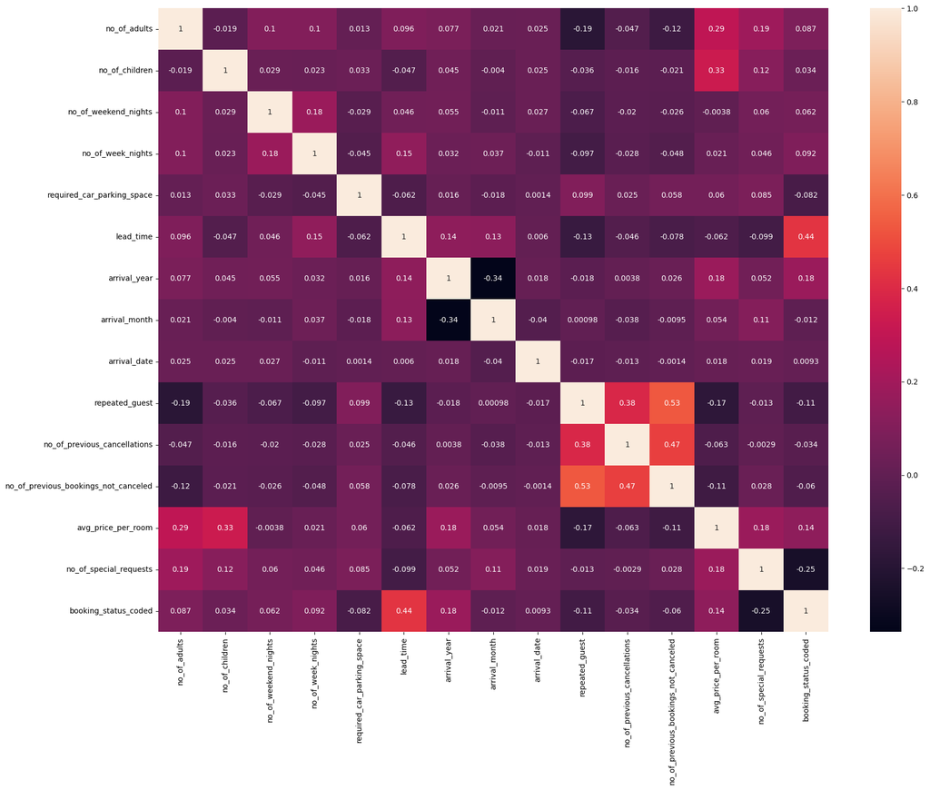

```python
#correlation matrix
plt.figure(figsize=(20,15))
sns.heatmap(hotels.corr(),annot=True)
```

The attributes with the strongest correlation to the coded booking status are:

1. Lead Time (0.44) - Longer the lead time, higher the occurence of cancellations
2. No of Special Requests (-0.25) - The more special requests made ahead of time, the lower the occurence of cancellations
3. Arrival Year - Bookings made in 2018 seem to be more correlated with cancellations compared to 2017
4. Average Price Per Room - Higher the price per room, higher the occurence of cancellations

### Calculate WOE and Information Value

```python
#bin attributes

def num_binning(df, attribute, n_bins):
    prefix = 'new'
    min_value = df[attribute].min()
    max_value = df[attribute].max()

    bins = np.linspace(min_value, max_value,n_bins+1)
    df[attribute+prefix] = pd.cut(df[attribute],bins=bins, include_lowest=True)

    df.drop(attribute,inplace=True,axis=1)
```

```python
numeric.extend(['Booking_ID','booking_status_coded'])
```

```python
#bin numeric columns

numeric_binned = hotels[numeric]

#only bin numerics with more than 5 unique variables
bin_attributes = []

for column in numeric_binned:
    if column not in ['Booking_ID','booking_status_coded']:
        if numeric_binned[column].nunique() > 6:
            bin_attributes.append(str(column))
```

```python
bin_attributes
```

```
['no_of_children',
 'no_of_weekend_nights',
 'no_of_week_nights',
 'lead_time',
 'arrival_month',
 'arrival_date',
 'no_of_previous_cancellations',
 'no_of_previous_bookings_not_canceled',
 'avg_price_per_room',
 'no_of_special_requests']
```

```python
#create bin key
attribute_bins = [6,3,4,5,4,3,3,3,3,3]
bin_key = dict(zip(bin_attributes, attribute_bins))
```

```python
#bin columns
for attribute, n_bins in bin_key.items():
    num_binning(numeric_binned,attribute,n_bins)
```

```python
numeric_binned.head()
```

|  | no_of_adults | required_car_parking_space | arrival_year | repeated_guest | Booking_ID | booking_status_coded | no_of_childrennew | no_of_weekend_nightsnew | no_of_week_nightsnew | lead_timenew | arrival_monthnew | arrival_datenew | no_of_previous_cancellationsnew | no_of_previous_bookings_not_cancelednew | avg_price_per_roomnew | no_of_special_requestsnew |
| --- | --- | --- | --- | --- | --- | --- | --- | --- | --- | --- | --- | --- | --- | --- | --- | --- |
| 0 | 1.845017 | 0.030698 | 2017.820431 | 0.025666 | INN00001 | 0 | (-0.001, 1.667] | (-0.001, 2.333] | (-0.001, 4.25] | (-0.001, 88.6] | (6.5, 9.25] | (11.0, 21.0] | (-0.001, 4.333] | (-0.001, 19.333] | (-0.001, 180.0] | (-0.001, 1.667] |
| 1 | 2.000000 | 0.000000 | 2018.000000 | 0.000000 | INN00002 | 0 | (-0.001, 1.667] | (-0.001, 2.333] | (-0.001, 4.25] | (-0.001, 88.6] | (9.25, 12.0] | (0.999, 11.0] | (-0.001, 4.333] | (-0.001, 19.333] | (-0.001, 180.0] | (-0.001, 1.667] |
| 2 | 1.000000 | 0.000000 | 2018.000000 | 0.000000 | INN00003 | 1 | (-0.001, 1.667] | (-0.001, 2.333] | (-0.001, 4.25] | (-0.001, 88.6] | (0.999, 3.75] | (21.0, 31.0] | (-0.001, 4.333] | (-0.001, 19.333] | (-0.001, 180.0] | (-0.001, 1.667] |
| 3 | 2.000000 | 0.000000 | 2018.000000 | 0.000000 | INN00004 | 1 | (-0.001, 1.667] | (-0.001, 2.333] | (-0.001, 4.25] | (177.2, 265.8] | (3.75, 6.5] | (11.0, 21.0] | (-0.001, 4.333] | (-0.001, 19.333] | (-0.001, 180.0] | (-0.001, 1.667] |
| 4 | 2.000000 | 0.000000 | 2018.000000 | 0.000000 | INN00005 | 1 | (-0.001, 1.667] | (-0.001, 2.333] | (-0.001, 4.25] | (-0.001, 88.6] | (3.75, 6.5] | (0.999, 11.0] | (-0.001, 4.333] | (-0.001, 19.333] | (-0.001, 180.0] | (-0.001, 1.667] |

```python
hotels_num_binned=numeric_binned
```

```python
hotels_num_binned.sample(20)
```

|  | no_of_adults | required_car_parking_space | arrival_year | repeated_guest | Booking_ID | booking_status_coded | no_of_childrennew | no_of_weekend_nightsnew | no_of_week_nightsnew | lead_timenew | arrival_monthnew | arrival_datenew | no_of_previous_cancellationsnew | no_of_previous_bookings_not_cancelednew | avg_price_per_roomnew | no_of_special_requestsnew |
| --- | --- | --- | --- | --- | --- | --- | --- | --- | --- | --- | --- | --- | --- | --- | --- | --- |
| 22698 | 2.000000 | 0.000000 | 2018.000000 | 0.0 | INN22699 | 1 | (-0.001, 1.667] | (-0.001, 2.333] | (-0.001, 4.25] | (-0.001, 88.6] | (9.25, 12.0] | (21.0, 31.0] | (-0.001, 4.333] | (-0.001, 19.333] | (-0.001, 180.0] | (-0.001, 1.667] |
| 36129 | 2.000000 | 0.000000 | 2018.000000 | 0.0 | INN36130 | 0 | (-0.001, 1.667] | (-0.001, 2.333] | (-0.001, 4.25] | (88.6, 177.2] | (3.75, 6.5] | (11.0, 21.0] | (-0.001, 4.333] | (-0.001, 19.333] | (-0.001, 180.0] | (1.667, 3.333] |
| 19299 | 2.000000 | 0.000000 | 2017.000000 | 0.0 | INN19300 | 0 | (-0.001, 1.667] | (-0.001, 2.333] | (-0.001, 4.25] | (177.2, 265.8] | (9.25, 12.0] | (0.999, 11.0] | (-0.001, 4.333] | (-0.001, 19.333] | (-0.001, 180.0] | (-0.001, 1.667] |
| 20527 | 1.000000 | 0.000000 | 2018.000000 | 0.0 | INN20528 | 0 | (-0.001, 1.667] | (-0.001, 2.333] | (-0.001, 4.25] | (88.6, 177.2] | (6.5, 9.25] | (21.0, 31.0] | (-0.001, 4.333] | (-0.001, 19.333] | (-0.001, 180.0] | (-0.001, 1.667] |
| 23960 | 2.000000 | 0.000000 | 2018.000000 | 0.0 | INN23961 | 1 | (-0.001, 1.667] | (-0.001, 2.333] | (-0.001, 4.25] | (-0.001, 88.6] | (3.75, 6.5] | (11.0, 21.0] | (-0.001, 4.333] | (-0.001, 19.333] | (-0.001, 180.0] | (-0.001, 1.667] |
| 7850 | 1.000000 | 0.000000 | 2018.000000 | 0.0 | INN07851 | 0 | (-0.001, 1.667] | (-0.001, 2.333] | (-0.001, 4.25] | (-0.001, 88.6] | (9.25, 12.0] | (11.0, 21.0] | (-0.001, 4.333] | (-0.001, 19.333] | (-0.001, 180.0] | (-0.001, 1.667] |
| 13722 | 2.000000 | 0.000000 | 2017.000000 | 0.0 | INN13723 | 0 | (-0.001, 1.667] | (-0.001, 2.333] | (-0.001, 4.25] | (-0.001, 88.6] | (9.25, 12.0] | (21.0, 31.0] | (-0.001, 4.333] | (-0.001, 19.333] | (-0.001, 180.0] | (-0.001, 1.667] |
| 31296 | 2.000000 | 0.000000 | 2017.820431 | 0.0 | INN31297 | 0 | (-0.001, 1.667] | (-0.001, 2.333] | (-0.001, 4.25] | (-0.001, 88.6] | (6.5, 9.25] | (11.0, 21.0] | (-0.001, 4.333] | (-0.001, 19.333] | (-0.001, 180.0] | (-0.001, 1.667] |
| 27001 | 2.000000 | 0.000000 | 2018.000000 | 0.0 | INN27002 | 1 | (-0.001, 1.667] | (-0.001, 2.333] | (-0.001, 4.25] | (177.2, 265.8] | (3.75, 6.5] | (21.0, 31.0] | (-0.001, 4.333] | (-0.001, 19.333] | (-0.001, 180.0] | (-0.001, 1.667] |
| 14055 | 1.000000 | 0.000000 | 2018.000000 | 0.0 | INN14056 | 0 | (-0.001, 1.667] | (-0.001, 2.333] | (-0.001, 4.25] | (-0.001, 88.6] | (0.999, 3.75] | (11.0, 21.0] | (-0.001, 4.333] | (-0.001, 19.333] | (-0.001, 180.0] | (-0.001, 1.667] |
| 18842 | 2.000000 | 0.000000 | 2018.000000 | 0.0 | INN18843 | 0 | (-0.001, 1.667] | (-0.001, 2.333] | (-0.001, 4.25] | (-0.001, 88.6] | (9.25, 12.0] | (21.0, 31.0] | (-0.001, 4.333] | (-0.001, 19.333] | (-0.001, 180.0] | (-0.001, 1.667] |
| 653 | 0.000000 | 0.000000 | 2018.000000 | 0.0 | INN00654 | 0 | (1.667, 3.333] | (-0.001, 2.333] | (-0.001, 4.25] | (-0.001, 88.6] | (6.5, 9.25] | (11.0, 21.0] | (-0.001, 4.333] | (-0.001, 19.333] | (-0.001, 180.0] | (-0.001, 1.667] |
| 9261 | 2.000000 | 0.000000 | 2018.000000 | 0.0 | INN09262 | 1 | (-0.001, 1.667] | (-0.001, 2.333] | (-0.001, 4.25] | (88.6, 177.2] | (3.75, 6.5] | (0.999, 11.0] | (-0.001, 4.333] | (-0.001, 19.333] | (-0.001, 180.0] | (-0.001, 1.667] |
| 32840 | 3.000000 | 0.000000 | 2018.000000 | 0.0 | INN32841 | 0 | (-0.001, 1.667] | (-0.001, 2.333] | (-0.001, 4.25] | (-0.001, 88.6] | (6.5, 9.25] | (11.0, 21.0] | (-0.001, 4.333] | (-0.001, 19.333] | (-0.001, 180.0] | (1.667, 3.333] |
| 10176 | 2.000000 | 0.000000 | 2017.820431 | 0.0 | INN10177 | 0 | (-0.001, 1.667] | (-0.001, 2.333] | (-0.001, 4.25] | (-0.001, 88.6] | (6.5, 9.25] | (11.0, 21.0] | (-0.001, 4.333] | (-0.001, 19.333] | (-0.001, 180.0] | (-0.001, 1.667] |
| 28072 | 1.845017 | 0.000000 | 2018.000000 | 0.0 | INN28073 | 1 | (-0.001, 1.667] | (-0.001, 2.333] | (4.25, 8.5] | (177.2, 265.8] | (6.5, 9.25] | (11.0, 21.0] | (-0.001, 4.333] | (-0.001, 19.333] | (-0.001, 180.0] | (1.667, 3.333] |
| 34329 | 2.000000 | 0.000000 | 2018.000000 | 0.0 | INN34330 | 1 | (1.667, 3.333] | (-0.001, 2.333] | (-0.001, 4.25] | (177.2, 265.8] | (6.5, 9.25] | (11.0, 21.0] | (-0.001, 4.333] | (-0.001, 19.333] | (-0.001, 180.0] | (1.667, 3.333] |
| 24682 | 3.000000 | 0.030698 | 2018.000000 | 0.0 | INN24683 | 0 | (-0.001, 1.667] | (-0.001, 2.333] | (-0.001, 4.25] | (-0.001, 88.6] | (0.999, 3.75] | (21.0, 31.0] | (-0.001, 4.333] | (-0.001, 19.333] | (-0.001, 180.0] | (-0.001, 1.667] |
| 23124 | 2.000000 | 0.000000 | 2018.000000 | 0.0 | INN23125 | 0 | (-0.001, 1.667] | (-0.001, 2.333] | (-0.001, 4.25] | (88.6, 177.2] | (9.25, 12.0] | (0.999, 11.0] | (-0.001, 4.333] | (-0.001, 19.333] | (-0.001, 180.0] | (1.667, 3.333] |
| 10244 | 1.000000 | 0.000000 | 2018.000000 | 0.0 | INN10245 | 0 | (-0.001, 1.667] | (-0.001, 2.333] | (-0.001, 4.25] | (-0.001, 88.6] | (3.75, 6.5] | (11.0, 21.0] | (-0.001, 4.333] | (-0.001, 19.333] | (-0.001, 180.0] | (-0.001, 1.667] |

```python
#define function to calculate WOE and IV from binned variables
def calc_iv (df, attribute, target):

    lst = []

    for i in range(df[attribute].nunique()):
        val = list(df[attribute].unique())[i]
        lst.append([attribute, val, df[df[attribute]==val].count()[attribute], df[(df[attribute]==val) & (df[target] == 1)].count()[attribute]])

    data = pd.DataFrame(lst, columns=['Variable','Value','Total_Count','Bad_Count'])

    data['Total_Share'] = data['Total_Count'] / data['Total_Count'].sum()
    data['Bad_Rate'] = data['Bad_Count'] / data['Total_Count']
    data['Bad Dist'] = data['Bad_Count'] / data['Bad_Count'].sum()
    data['Good Dist'] = (data['Total_Count'] - data['Bad_Count']) / (data['Total_Count'].sum() - data['Bad_Count'].sum())
    data['WOE'] = np.log(data['Good Dist'] / data['Bad Dist'])
    data['IV'] = (data['WOE'] * (data['Good Dist'] - data['Bad Dist'])).sum()

    data = data.sort_values(by=['Variable','Value'])

    return data
```

```python
#merge binned numeric dataframe with categorical columns
non_numeric.append('Booking_ID')
hotels_binned = hotels_num_binned.merge(hotels[non_numeric],on='Booking_ID',how='outer')
```

```python
hotels_binned.head()
```

|  | no_of_adults | required_car_parking_space | arrival_year | repeated_guest | Booking_ID | booking_status_coded | no_of_childrennew | no_of_weekend_nightsnew | no_of_week_nightsnew | lead_timenew | arrival_monthnew | arrival_datenew | no_of_previous_cancellationsnew | no_of_previous_bookings_not_cancelednew | avg_price_per_roomnew | no_of_special_requestsnew | type_of_meal_plan | room_type_reserved | market_segment_type |
| --- | --- | --- | --- | --- | --- | --- | --- | --- | --- | --- | --- | --- | --- | --- | --- | --- | --- | --- | --- |
| 0 | 1.845017 | 0.030698 | 2017.820431 | 0.025666 | INN00001 | 0 | (-0.001, 1.667] | (-0.001, 2.333] | (-0.001, 4.25] | (-0.001, 88.6] | (6.5, 9.25] | (11.0, 21.0] | (-0.001, 4.333] | (-0.001, 19.333] | (-0.001, 180.0] | (-0.001, 1.667] | Meal Plan 1 | Room_Type 1 | Online |
| 1 | 2.000000 | 0.000000 | 2018.000000 | 0.000000 | INN00002 | 0 | (-0.001, 1.667] | (-0.001, 2.333] | (-0.001, 4.25] | (-0.001, 88.6] | (9.25, 12.0] | (0.999, 11.0] | (-0.001, 4.333] | (-0.001, 19.333] | (-0.001, 180.0] | (-0.001, 1.667] | Not Selected | Room_Type 1 | Online |
| 2 | 1.000000 | 0.000000 | 2018.000000 | 0.000000 | INN00003 | 1 | (-0.001, 1.667] | (-0.001, 2.333] | (-0.001, 4.25] | (-0.001, 88.6] | (0.999, 3.75] | (21.0, 31.0] | (-0.001, 4.333] | (-0.001, 19.333] | (-0.001, 180.0] | (-0.001, 1.667] | Meal Plan 1 | Room_Type 1 | Online |
| 3 | 2.000000 | 0.000000 | 2018.000000 | 0.000000 | INN00004 | 1 | (-0.001, 1.667] | (-0.001, 2.333] | (-0.001, 4.25] | (177.2, 265.8] | (3.75, 6.5] | (11.0, 21.0] | (-0.001, 4.333] | (-0.001, 19.333] | (-0.001, 180.0] | (-0.001, 1.667] | Meal Plan 1 | Room_Type 1 | Online |
| 4 | 2.000000 | 0.000000 | 2018.000000 | 0.000000 | INN00005 | 1 | (-0.001, 1.667] | (-0.001, 2.333] | (-0.001, 4.25] | (-0.001, 88.6] | (3.75, 6.5] | (0.999, 11.0] | (-0.001, 4.333] | (-0.001, 19.333] | (-0.001, 180.0] | (-0.001, 1.667] | Not Selected | Room_Type 1 | Online |

```python
#create IV dataframe

attribute_IV = pd.DataFrame()

for column in hotels_binned:

    if column not in ['Booking_ID','booking_status_coded']:
        data = calc_iv(hotels_binned, column, 'booking_status_coded')
        attribute_IV = attribute_IV.append(data)
```

```python
attribute_IV
```

|  | Variable | Value | Total_Count | Bad_Count | Total_Share | Bad_Rate | Bad Dist | Good Dist | WOE | IV |
| --- | --- | --- | --- | --- | --- | --- | --- | --- | --- | --- |
| 4 | no_of_adults | 0.0 | 137 | 42 | 0.003777 | 0.306569 | 0.003534 | 0.003895 | 0.097311 | 0.044824 |
| 2 | no_of_adults | 1.0 | 7606 | 1833 | 0.209676 | 0.240994 | 0.154228 | 0.236695 | 0.428342 | 0.044824 |
| 0 | no_of_adults | 1.845017 | 413 | 140 | 0.011385 | 0.338983 | 0.011780 | 0.011193 | -0.051067 | 0.044824 |
| 1 | no_of_adults | 2.0 | 25813 | 9015 | 0.711592 | 0.349243 | 0.758519 | 0.688725 | -0.096526 | 0.044824 |
| 3 | no_of_adults | 3.0 | 2290 | 852 | 0.063129 | 0.372052 | 0.071687 | 0.058959 | -0.195474 | 0.044824 |
| ... | ... | ... | ... | ... | ... | ... | ... | ... | ... | ... |
| 3 | market_segment_type | Aviation | 122 | 36 | 0.003363 | 0.295082 | 0.003029 | 0.003526 | 0.151932 | inf |
| 4 | market_segment_type | Complementary | 375 | 0 | 0.010338 | 0.000000 | 0.000000 | 0.015375 | inf | inf |
| 2 | market_segment_type | Corporate | 1926 | 204 | 0.053094 | 0.105919 | 0.017164 | 0.070603 | 1.414226 | inf |
| 1 | market_segment_type | Offline | 10076 | 3023 | 0.277767 | 0.300020 | 0.254354 | 0.289176 | 0.128307 | inf |
| 0 | market_segment_type | Online | 23776 | 8622 | 0.655438 | 0.362635 | 0.725452 | 0.621320 | -0.154949 | inf |

65 rows × 10 columns

```python
IV_rank = attribute_IV[['Variable','IV']].drop_duplicates(ignore_index=True)
IV_rank.sort_values(by='IV',inplace=True,ascending=False)
```

```python
IV_rank
```

|  | Variable | IV |
| --- | --- | --- |
| 16 | market_segment_type | inf |
| 13 | no_of_special_requestsnew | inf |
| 11 | no_of_previous_bookings_not_cancelednew | inf |
| 10 | no_of_previous_cancellationsnew | inf |
| 7 | lead_timenew | 0.815953 |
| 2 | arrival_year | 0.175756 |
| 3 | repeated_guest | 0.119140 |
| 8 | arrival_monthnew | 0.076462 |
| 0 | no_of_adults | 0.044824 |
| 1 | required_car_parking_space | 0.043130 |
| 14 | type_of_meal_plan | 0.032348 |
| 6 | no_of_week_nightsnew | 0.023163 |
| 5 | no_of_weekend_nightsnew | 0.015755 |
| 15 | room_type_reserved | 0.006910 |
| 4 | no_of_childrennew | 0.006369 |
| 12 | avg_price_per_roomnew | 0.002015 |
| 9 | arrival_datenew | 0.001602 |

IV legend:

- Less than 0.02 - Not useful for prediction
- 0.02 to 0.1 - Weak predictive power
- 0.1 to 0.3 - Medium predictive power
- 0.3 to 0.5 - Strong predictive power
- Greater than 0.5 Suspicious predictive power

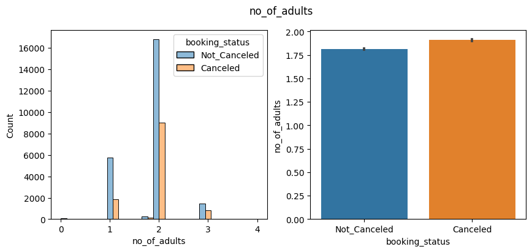

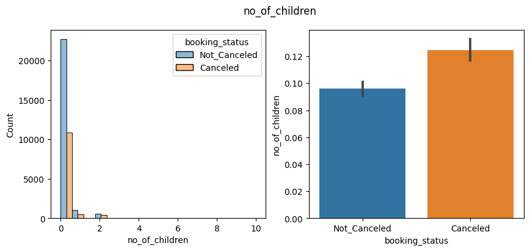

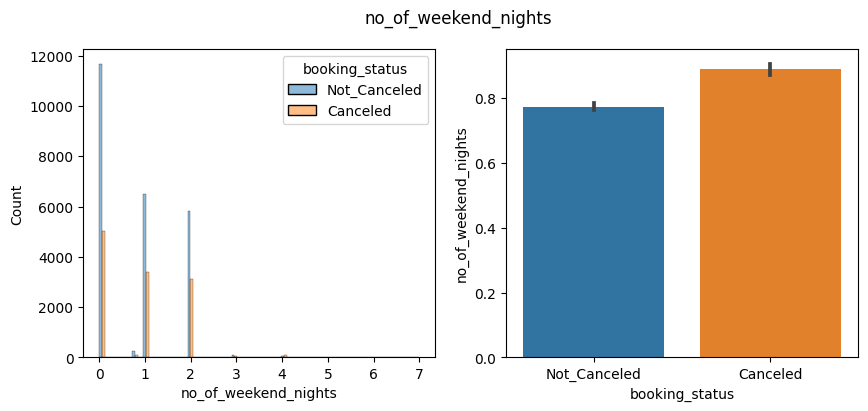

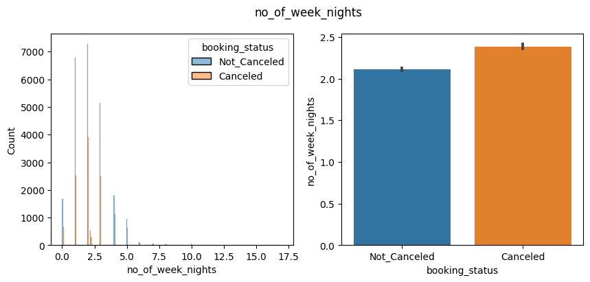

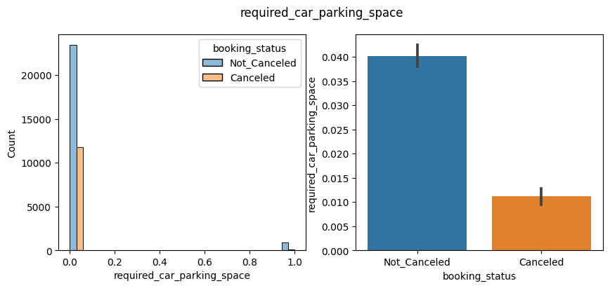

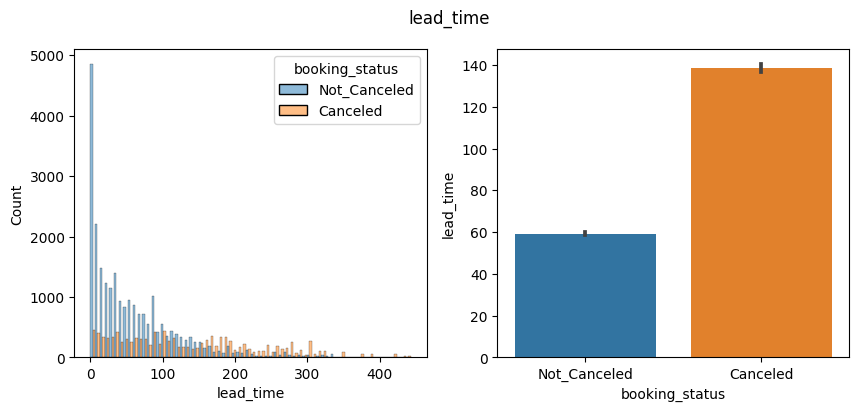

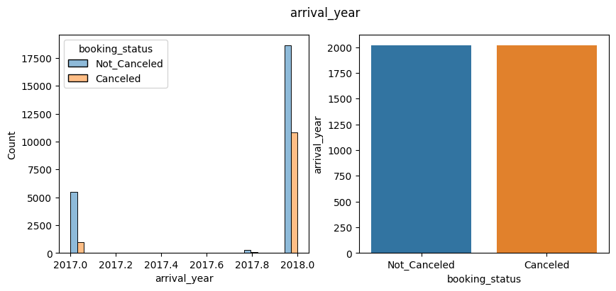

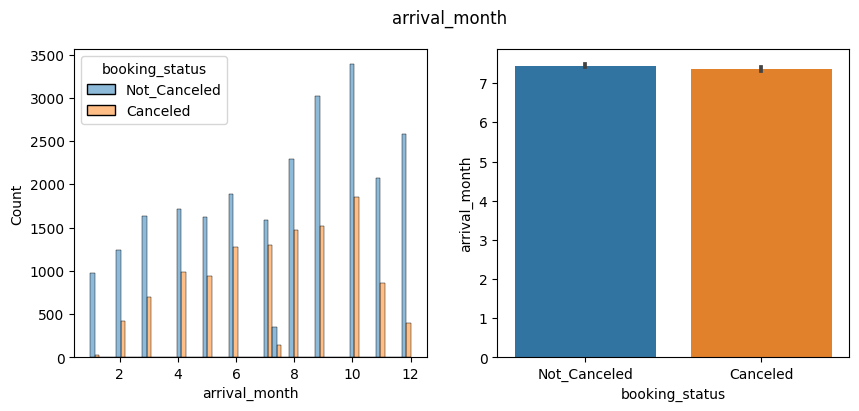

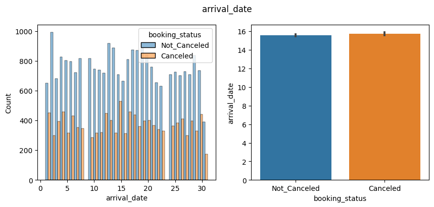

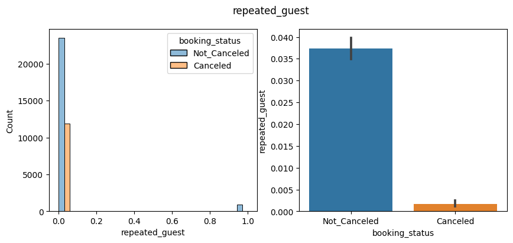

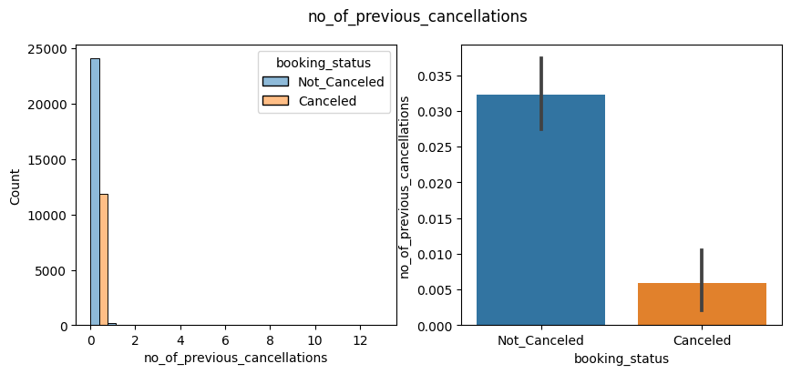

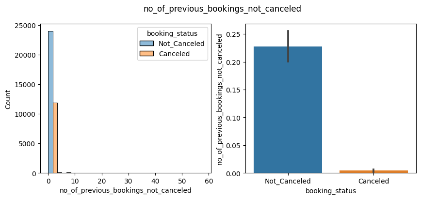

[2 more figures not shown]

```python
#graph all numeric features against booking_status

for col in numeric:
    if col not in ['Booking_ID','booking_status_coded']:
        plt.figure(figsize=(10,4))
        plt.subplot(1,2,1)
        sns.histplot(data=hotels,x=col,hue='booking_status',alpha=0.5,multiple='dodge')

        plt.subplot(1,2,2)
        sns.barplot(data=hotels,x='booking_status',y=col)

        plt.suptitle(col)
```

## Create Predictive Model

```python
from sklearn.linear_model import LogisticRegression
from sklearn.model_selection import train_test_split
from sklearn.metrics import confusion_matrix
from sklearn.metrics import plot_confusion_matrix

X_train, X_test, y_train, y_test = train_test_split(
    hotels[['lead_time','arrival_year','repeated_guest']],
    hotels['booking_status'],
    train_size=0.95
)
```

```
Accuracy of logistic regression classifier:  0.7624035281146637
```

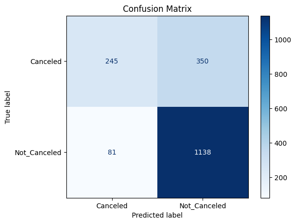

```python
logreg = LogisticRegression().fit(X=X_train, y=y_train)
y_pred = logreg.predict(X_test)

print("Accuracy of logistic regression classifier: ", logreg.score(X_test, y_test))

matrix = plot_confusion_matrix(logreg, X_test, y_test, cmap=plt.cm.Blues)
plt.title('Confusion Matrix')
plt.show()
```

Null Hypothesis = Booking is not cancelled